[Back to home page](https://rosanoel.github.io/)

# Breast cancer Wisconsin dataset - Classification

*Author : Rosalie Noel*

# Executive summary

1 in 8 women in New South Wales will develop breast cancer in their lifetime[*](https://www.breastscreen.nsw.gov.au/about-breast-cancer). An early diagnosis and prompt treatement is critical for the patient's survival outlook. The 5-year relative survival rate for women with stage 0 or stage I breast cancer is close to 100%[*](https://www.cancer.org/cancer/breast-cancer/understanding-a-breast-cancer-diagnosis/breast-cancer-survival-rates.html), while this rate drops to around 22% when the cancer has spread to other parts of the body (stage IV).

This project is based on the [Breast Cancer Wisconsin](https://www.kaggle.com/uciml/breast-cancer-wisconsin-data) dataset, published by UCI Machine learning. The dataset contains information extracted from digitized image of breast mass cell nuclei, along with the associated diagnosis (Benign / Malignant). With 569 samples, it is a pretty small dataset. It is relatively balanced with 357 benign and 212 malignant observations.

This was one of my first projects in Python. It gave me the opportunity to explore the implementation and tuning of supervised classification algorithms in this language.

In a second iteration, I ensembled the 3 best performers with majority vote classifier. This improved model was able to detect all the malignant cases in the sample (100% recall). It achieved a global accuracy score of 98%, as 7% of the samples labeled as malignant by the model were actually benign.

1. Load the data, manage the missing values
2. Exploratory Data Analysis  
   2.1. Distribution of the Response  
   2.2 Pairwise correlations  
   2.3 Variable importance analysis with a random forest  
   2.4 Relationship between area, perimeter and radius  
   2.5 Relationship between _se, _mean, and _worst values  
   2.6 Conclusion
3. Preparation of the predictive modelling  
   3.1 Performance measurement strategy  
   3.2 Train - test split  
   3.3 Pre-processing: Normalise, center and scale
4. Predictive analysis: Base models  
   4.1 Preliminaries  
   4.2 Naive Bayes  
   4.3 Support vector machine  
   4.4 Logistic regression  
   4.5 Classification tree  
   4.6 Random forest  
   4.7 XGBoost  
   4.8 Results
5. Round two - Majority vote classifier
6. Conclusion

# Load the data, manage the missing values

First, let's load the data and have a quick look at them.

```python
#Import libraries
import pandas as pd
import numpy as np
import os
import time
import math

import matplotlib.pyplot as plt
import matplotlib as mpl
import warnings
warnings.filterwarnings("ignore") #just for the creation of the html page
import seaborn as sns;
os.chdir('D:\data science\Breast cancer')

#load the data
data= pd.read_csv('data.csv')
print('The raw dataset contains ',data.shape[0], ' observations of ',data.shape[1], ' variables.')
```

```
The raw dataset contains  569  observations of  33  variables.
```

```python
#variables names and overview of the dataset
cols = data.columns
print(cols)
data.head(7)
```

```
Index(['id', 'diagnosis', 'radius_mean', 'texture_mean', 'perimeter_mean',
       'area_mean', 'smoothness_mean', 'compactness_mean', 'concavity_mean',
       'concave points_mean', 'symmetry_mean', 'fractal_dimension_mean',
       'radius_se', 'texture_se', 'perimeter_se', 'area_se', 'smoothness_se',
       'compactness_se', 'concavity_se', 'concave points_se', 'symmetry_se',
       'fractal_dimension_se', 'radius_worst', 'texture_worst',
       'perimeter_worst', 'area_worst', 'smoothness_worst',
       'compactness_worst', 'concavity_worst', 'concave points_worst',
       'symmetry_worst', 'fractal_dimension_worst', 'Unnamed: 32'],
      dtype='object')
```

|  | id | diagnosis | radius_mean | texture_mean | perimeter_mean | area_mean | smoothness_mean | compactness_mean | concavity_mean | concave points_mean | ... | texture_worst | perimeter_worst | area_worst | smoothness_worst | compactness_worst | concavity_worst | concave points_worst | symmetry_worst | fractal_dimension_worst | Unnamed: 32 |
| --- | --- | --- | --- | --- | --- | --- | --- | --- | --- | --- | --- | --- | --- | --- | --- | --- | --- | --- | --- | --- | --- |
| 0 | 842302 | M | 17.99 | 10.38 | 122.80 | 1001.0 | 0.11840 | 0.27760 | 0.3001 | 0.14710 | ... | 17.33 | 184.60 | 2019.0 | 0.1622 | 0.6656 | 0.7119 | 0.2654 | 0.4601 | 0.11890 | NaN |
| 1 | 842517 | M | 20.57 | 17.77 | 132.90 | 1326.0 | 0.08474 | 0.07864 | 0.0869 | 0.07017 | ... | 23.41 | 158.80 | 1956.0 | 0.1238 | 0.1866 | 0.2416 | 0.1860 | 0.2750 | 0.08902 | NaN |
| 2 | 84300903 | M | 19.69 | 21.25 | 130.00 | 1203.0 | 0.10960 | 0.15990 | 0.1974 | 0.12790 | ... | 25.53 | 152.50 | 1709.0 | 0.1444 | 0.4245 | 0.4504 | 0.2430 | 0.3613 | 0.08758 | NaN |
| 3 | 84348301 | M | 11.42 | 20.38 | 77.58 | 386.1 | 0.14250 | 0.28390 | 0.2414 | 0.10520 | ... | 26.50 | 98.87 | 567.7 | 0.2098 | 0.8663 | 0.6869 | 0.2575 | 0.6638 | 0.17300 | NaN |
| 4 | 84358402 | M | 20.29 | 14.34 | 135.10 | 1297.0 | 0.10030 | 0.13280 | 0.1980 | 0.10430 | ... | 16.67 | 152.20 | 1575.0 | 0.1374 | 0.2050 | 0.4000 | 0.1625 | 0.2364 | 0.07678 | NaN |
| 5 | 843786 | M | 12.45 | 15.70 | 82.57 | 477.1 | 0.12780 | 0.17000 | 0.1578 | 0.08089 | ... | 23.75 | 103.40 | 741.6 | 0.1791 | 0.5249 | 0.5355 | 0.1741 | 0.3985 | 0.12440 | NaN |
| 6 | 844359 | M | 18.25 | 19.98 | 119.60 | 1040.0 | 0.09463 | 0.10900 | 0.1127 | 0.07400 | ... | 27.66 | 153.20 | 1606.0 | 0.1442 | 0.2576 | 0.3784 | 0.1932 | 0.3063 | 0.08368 | NaN |

7 rows × 33 columns

```python
#manage the missing data
missing = data.isnull().sum().sort_values(ascending=False)
print('missing values: ' ,missing.drop(missing[missing==0].index))
```

```
missing values:  Unnamed: 32    569
dtype: int64
```

There is one variable with missing values in the dataset: 'Unnamed: 32'. All the observations are missing for this variable.

We will remove :

- **id**, which brings no information for predictive purpose
- **Unnamed 32**, which does not contain any value

There are no other missing values.

```python
#removing variables
data = data.drop(['id', 'Unnamed: 32'],axis=1)
```

```python
data.describe()
```

|  | radius_mean | texture_mean | perimeter_mean | area_mean | smoothness_mean | compactness_mean | concavity_mean | concave points_mean | symmetry_mean | fractal_dimension_mean | ... | radius_worst | texture_worst | perimeter_worst | area_worst | smoothness_worst | compactness_worst | concavity_worst | concave points_worst | symmetry_worst | fractal_dimension_worst |
| --- | --- | --- | --- | --- | --- | --- | --- | --- | --- | --- | --- | --- | --- | --- | --- | --- | --- | --- | --- | --- | --- |
| count | 569.000000 | 569.000000 | 569.000000 | 569.000000 | 569.000000 | 569.000000 | 569.000000 | 569.000000 | 569.000000 | 569.000000 | ... | 569.000000 | 569.000000 | 569.000000 | 569.000000 | 569.000000 | 569.000000 | 569.000000 | 569.000000 | 569.000000 | 569.000000 |
| mean | 14.127292 | 19.289649 | 91.969033 | 654.889104 | 0.096360 | 0.104341 | 0.088799 | 0.048919 | 0.181162 | 0.062798 | ... | 16.269190 | 25.677223 | 107.261213 | 880.583128 | 0.132369 | 0.254265 | 0.272188 | 0.114606 | 0.290076 | 0.083946 |
| std | 3.524049 | 4.301036 | 24.298981 | 351.914129 | 0.014064 | 0.052813 | 0.079720 | 0.038803 | 0.027414 | 0.007060 | ... | 4.833242 | 6.146258 | 33.602542 | 569.356993 | 0.022832 | 0.157336 | 0.208624 | 0.065732 | 0.061867 | 0.018061 |
| min | 6.981000 | 9.710000 | 43.790000 | 143.500000 | 0.052630 | 0.019380 | 0.000000 | 0.000000 | 0.106000 | 0.049960 | ... | 7.930000 | 12.020000 | 50.410000 | 185.200000 | 0.071170 | 0.027290 | 0.000000 | 0.000000 | 0.156500 | 0.055040 |
| 25% | 11.700000 | 16.170000 | 75.170000 | 420.300000 | 0.086370 | 0.064920 | 0.029560 | 0.020310 | 0.161900 | 0.057700 | ... | 13.010000 | 21.080000 | 84.110000 | 515.300000 | 0.116600 | 0.147200 | 0.114500 | 0.064930 | 0.250400 | 0.071460 |
| 50% | 13.370000 | 18.840000 | 86.240000 | 551.100000 | 0.095870 | 0.092630 | 0.061540 | 0.033500 | 0.179200 | 0.061540 | ... | 14.970000 | 25.410000 | 97.660000 | 686.500000 | 0.131300 | 0.211900 | 0.226700 | 0.099930 | 0.282200 | 0.080040 |
| 75% | 15.780000 | 21.800000 | 104.100000 | 782.700000 | 0.105300 | 0.130400 | 0.130700 | 0.074000 | 0.195700 | 0.066120 | ... | 18.790000 | 29.720000 | 125.400000 | 1084.000000 | 0.146000 | 0.339100 | 0.382900 | 0.161400 | 0.317900 | 0.092080 |
| max | 28.110000 | 39.280000 | 188.500000 | 2501.000000 | 0.163400 | 0.345400 | 0.426800 | 0.201200 | 0.304000 | 0.097440 | ... | 36.040000 | 49.540000 | 251.200000 | 4254.000000 | 0.222600 | 1.058000 | 1.252000 | 0.291000 | 0.663800 | 0.207500 |

8 rows × 30 columns

# Exploratory data analysis

First, let's have a look at the **distribution of the diagnostic** among the dataset. Then, we will analyse **pairwise correlations**, and examine **which variables are the most important** for accuately predicting the diagnosis.

We will then explore some **relationships** more specific to this particular dataset:

- The relationship between the radius, perimeter and area variables,
- The relationship between 'mean', 'se' and 'worst' measurement of the same quantities.

## Distribution of the response

Let's first have a look at the distribution of the diagnosis within the data.

```python
#distribution of diagnosis

print(data.diagnosis.value_counts(normalize=True))
```

```
B    0.627417
M    0.372583
Name: diagnosis, dtype: float64
```

The dataset is relatively balanced with broadly **37% of the observations** being malignant.

## Pairwise correlations

Let's build a table that displays the pairwise correlations between the variables, sorted by importance. We will only display the pairs that have a absolute correlation higher then 80%.

```python
#Pairwise correlations

core = data.corr()  #correlation matrix
c1 = core.unstack() #flattened
c1=c1[(c1!=1)&(abs(c1)>0.8)]# cutout for high correlation set at 80%
c1.sort_values(ascending = False).drop_duplicates()
```

```
radius_mean              perimeter_mean          0.997855
perimeter_worst          radius_worst            0.993708
radius_mean              area_mean               0.987357
perimeter_mean           area_mean               0.986507
radius_worst             area_worst              0.984015
area_worst               perimeter_worst         0.977578
perimeter_se             radius_se               0.972794
perimeter_mean           perimeter_worst         0.970387
radius_worst             radius_mean             0.969539
perimeter_mean           radius_worst            0.969476
radius_mean              perimeter_worst         0.965137
area_mean                radius_worst            0.962746
                         area_worst              0.959213
                         perimeter_worst         0.959120
radius_se                area_se                 0.951830
area_worst               perimeter_mean          0.941550
radius_mean              area_worst              0.941082
area_se                  perimeter_se            0.937655
concave points_mean      concavity_mean          0.921391
texture_worst            texture_mean            0.912045
concave points_mean      concave points_worst    0.910155
concavity_worst          compactness_worst       0.892261
                         concavity_mean          0.884103
compactness_mean         concavity_mean          0.883121
compactness_worst        compactness_mean        0.865809
concavity_mean           concave points_worst    0.861323
concave points_mean      perimeter_worst         0.855923
concave points_worst     concavity_worst         0.855434
perimeter_mean           concave points_mean     0.850977
compactness_mean         concave points_mean     0.831135
concave points_mean      radius_worst            0.830318
                         area_mean               0.823269
                         radius_mean             0.822529
concave points_worst     perimeter_worst         0.816322
compactness_mean         concavity_worst         0.816275
                         concave points_worst    0.815573
area_worst               area_se                 0.811408
fractal_dimension_worst  compactness_worst       0.810455
concave points_mean      area_worst              0.809630
smoothness_mean          smoothness_worst        0.805324
compactness_se           fractal_dimension_se    0.803269
                         concavity_se            0.801268
compactness_worst        concave points_worst    0.801080
area_mean                area_se                 0.800086
dtype: float64
```

We can observe a very high degree of correlation within the dataset:

- The **radius / perimeter / area** variables are correlated in general. We will explore in a next section the relationship between those variables
- The **mean** and **worst** values are usually highly correlated for the same variable. Worst is defined in the dataset description as the mean of the 3 most severe points. We will explore this further in a next section.
- **Concavity** (severity of concave portions of the contour) and **concave points** (number of concave portions of the contour) are highly correlated. In a true business case, I would like to validate with the team who has produced the measurement if this is the most optimal way to summarize the concavity informations, or if there is an opportunity to help them develop more discriminant metrics.

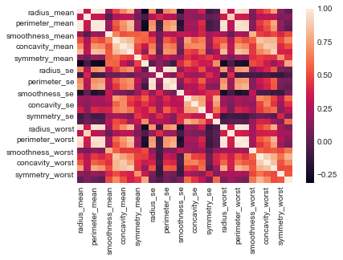

```python
sns.heatmap(core)
```

## Variable importance analysis with a random forest

Fitting a random forest is a common way to get a quick assessment of the variable importance in a dataset. It is a flexible algorithm, easy to implement, which produces easily interpretable results.

```python
from sklearn.ensemble import RandomForestClassifier
quickrf=RandomForestClassifier()
response = data['diagnosis']
variables = data.drop('diagnosis',axis=1)
quickrf.fit(variables,response)#fitted on entire dataset, because I do the train/test split later.
#I don't expect a huge ifference in terms of var importance
varimp  = pd.DataFrame(quickrf.feature_importances_,
                                   index = variables.columns,
                                    columns=['importance']).sort_values('importance',ascending=False)
varimp
```

|  | importance |
| --- | --- |
| perimeter_worst | 0.248553 |
| area_worst | 0.170510 |
| radius_worst | 0.129125 |
| area_se | 0.074085 |
| concavity_worst | 0.063996 |
| concave points_worst | 0.058685 |
| radius_se | 0.040586 |
| texture_mean | 0.028522 |
| texture_worst | 0.019601 |
| compactness_worst | 0.018024 |
| perimeter_mean | 0.015305 |
| symmetry_worst | 0.014790 |
| fractal_dimension_worst | 0.014198 |
| smoothness_worst | 0.012790 |
| concavity_mean | 0.010253 |
| smoothness_se | 0.009370 |
| smoothness_mean | 0.009149 |
| fractal_dimension_se | 0.008755 |
| concave points_se | 0.008062 |
| area_mean | 0.007541 |
| concave points_mean | 0.007262 |
| perimeter_se | 0.006756 |
| fractal_dimension_mean | 0.006039 |
| concavity_se | 0.004058 |
| symmetry_se | 0.003466 |
| compactness_se | 0.003449 |
| symmetry_mean | 0.002264 |
| radius_mean | 0.002071 |
| compactness_mean | 0.001846 |
| texture_se | 0.000889 |

There are some interesting insights to observe from the table above:

- Between mean, se and worst observations, we can see that the **worst values** are the ones that have the highest predictive importance.
- We can also see that the **concavity** of the cell is very important for the diagnosis. I wonder how this relates with the information contained within area, perimeter and radius. We will explore this intuition further in the next section.

## Relationship between area, perimeter and radius

Let's take a closer look to the relationship between the area, perimeter and radius variables

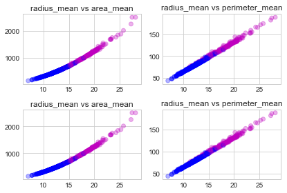

```python
fig, axes = plt.subplots(nrows=2, ncols=2)

axes[0, 0].set_title('radius_mean vs area_mean')
axes[0, 0].scatter(data.radius_mean,data.area_mean, c = data.diagnosis, alpha =0.3)

axes[0,1].set_title('radius_mean vs perimeter_mean')
axes[0, 1].scatter(data.radius_mean,data.perimeter_mean, c = data.diagnosis, alpha =0.3)

axes[1, 0].set_title('radius_mean vs area_mean')
axes[1, 0].scatter(data.radius_mean,data.area_mean, c = data.diagnosis, alpha =0.3)

axes[1,1].set_title('radius_mean vs perimeter_mean')
axes[1, 1].scatter(data.radius_mean,data.perimeter_mean, c = data.diagnosis, alpha =0.3)
plt.tight_layout()
```

We can observe a relationship that looks **quadratic** between **radius and area**, and a direct **linear** relationship between **radius and perimeter**. We could also assess the **cell deformation** from the perimeter and area variables: does the deviation from the theoretical **circle quantities** contain any hidden predictive information about the diagnosis?

Let's explore further this intuition:

1. Can we validate that the relationship between radius and area is a quadratic one?
2. What does the deviation between the theoretical perimeter ($2 \pi r$) and area ($\pi r^2$) quantities, and the observed radius, perimeter, and area values tell us about diagnosis?

```
 --- Correlations: ---
correlation between root area and radius:  99.88%
correlation between perimeter and radius:  99.37%
 --- Comparison between theoretical circle values and observed data: ---
average deviation between circle perimeter and observed perimeter:  -4.237%
average deviation between circle area and observed area:  1.421%
```

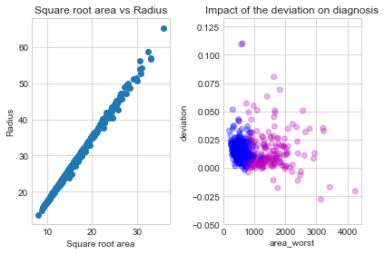

```python
# -- square root and correlation --
sqrt_area_worst = data.area_worst**(0.5)
print(' --- Correlations: ---')
print("correlation between root area and radius: ",'{:.2%}'.format(np.corrcoef(data.radius_worst, sqrt_area_worst)[0][1]))
print("correlation between perimeter and radius: ",'{:.2%}'.format(np.corrcoef(data.perimeter_worst, data.radius_worst)[0][1]))

# -- comparison with cicle values 2pi*r and pi* r^2 --
fract_peri = 2*math.pi*data.radius_worst/data.perimeter_worst-1
fract_area = np.sqrt(math.pi)*data.radius_worst/sqrt_area_worst-1
print(' --- Comparison between theoretical circle values and observed data: ---')
print('average deviation between circle perimeter and observed perimeter: ','{:.3%}'.format(np.mean(fract_peri)))
print('average deviation between circle area and observed area: ','{:.3%}'.format(np.mean(fract_area)))

# -- any pattern with diagnosis? --
fig, axes = plt.subplots(nrows=1, ncols=2)
axes[0].set_title('Square root area vs Radius')
axes[0].set(xlabel='Square root area', ylabel='Radius')
axes[0].scatter(data.radius_worst,sqrt_area_worst)
axes[1].set_title('Impact of the deviation on diagnosis')
axes[1].set(xlabel='area_worst', ylabel='deviation')
axes[1].scatter(x=data.area_worst,y=fract_area, c = data.diagnosis, alpha =0.3)
plt.tight_layout()
```

This confirms the intuition: there is a direct linear relationship between radius and perimeter (99.3%) and a quadratic one between radius and area (99.8%).

However, as we can observe on the right plot, the deviance from a round shape does not contain any significant information about the diagnosis. (No particular pattern along the y axis)

## Relationship between _se, _mean, and _worst values

Let's explore the relationship between _se, _mean and _worst observations in the dataset. According to the data description, those represent the standard deviation, mean, and average of the three largest values respectively for each attribute.  
We will explore this relationship for a sample of variables: smoothness, concavity, texture and area

```
()
```

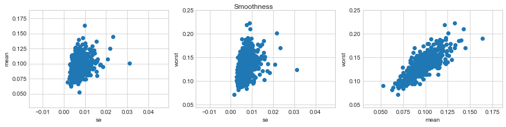

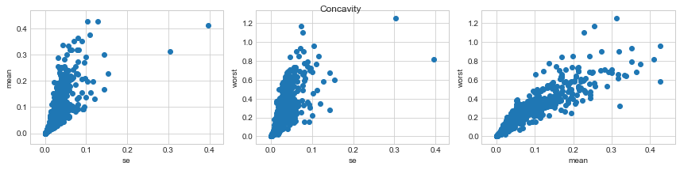

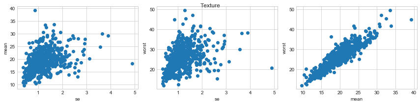

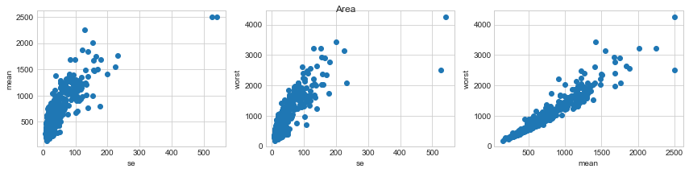

```python
# -- definition of a custom plot function
def pairs(dat,title):
    se = dat.filter(regex='_se')
    mean = dat.filter(regex='_mean')
    worst = dat.filter(regex='_worst')
    figpairs, axes = plt.subplots( ncols=3,figsize=(12,3))
    axes[0].scatter(se,mean)
    axes[0].set(xlabel='se', ylabel='mean')
    axes[1].scatter(se,worst)
    axes[1].set(xlabel='se', ylabel='worst')
    axes[2].scatter(mean,worst)
    axes[2].set(xlabel='mean', ylabel='worst')
    figpairs.suptitle(title)
    plt.tight_layout()
    return ()

# -- call the plot function for each var I want to explore
pairs(data.filter(regex='smoothness'),'Smoothness')
pairs(data.filter(regex='concavity'),'Concavity')
pairs(data.filter(regex='texture'),'Texture')
pairs(data.filter(regex='area'),'Area')
```

We can observe on the plots below that there is usually a strong relationship between **_mean and _worst**. The relationship is not really conclusive between se and the other variables.

## Conclusion

Based on the analysis above, we will address the correlation in the dataset by:

- removing the **perimeter** variables, as they are direclty linked to the **radius** ones,
- removing the **_mean** variables.

```python
#--- identify the variables that will be removed
perimetervar= data.filter(regex='perimeter').columns
meanvar = data.filter(regex='_mean').columns
meanvar = meanvar.difference(perimetervar) #remove common elements

#--- drop the variables
print('The dataset contains',data.shape[1], ' variables before removal.')
print('--------------')
print('The following variables will be removed',perimetervar,meanvar)
data=data.drop(perimetervar,axis=1)
data=data.drop(meanvar,axis=1)
print('--------------')
print('The dataset contains',data.shape[1], ' variables after removal.')
```

```
The dataset contains 31  variables before removal.
--------------
The following variables will be removed Index(['perimeter_mean', 'perimeter_se', 'perimeter_worst'], dtype='object') Index(['area_mean', 'compactness_mean', 'concave points_mean',
       'concavity_mean', 'fractal_dimension_mean', 'radius_mean',
       'smoothness_mean', 'symmetry_mean', 'texture_mean'],
      dtype='object')
--------------
The dataset contains 19  variables after removal.
```

Note that I had also explored dimensionality reduction with a PCA, but this did not improve the predictive power of the models, while this unsupervised thechnique has a cost in terms of interpretability.

# Preparation of the predictive modelling

## Performance measurement strategy

A commonly used performance metric is the classification **accuracy**, defined as the percentage of observation correctly classified. A naive algorithm that would classify every observation as benign, would achieve a 63% accuracy on this dataset, which is the proportion of benign observations.

This is not the measure that we will adopt for this dataset, as we want to **focus on the detection of all malignant cells**. We are ready to accept (**False Positive**), i.e., at the cost of a stressful experience, a patient would be tagged as positive, sent to additional screening and then cleared for breast cancer. But we absolutely want to avoid (**False Negative**), where a patient is diagnosed with breast cancer and therefore is not receiving appropriate treatement.

With this constraint in mind, we use the following metrics to assess the quality of the classifiers:

**Sensitivity / Recall**

This is the models's ability to classify as positive when the result is actually positive. More formally:

$Sensitivity = \frac{True \ Positives}{True \ Positives \ + \ False \ Negatives} = \frac{Number \ of \ malignant \ cells \ detected \ as \ malignant}{Total \ number \ of \ malignant \ cells}$

**F1 Score**

This is the balance between precision (percentage of true positives among results predicted as positive) and recall, expressed as a weighted harmonic mean of both quantities:

$F1 = 2 \ \times \frac{precision \ \times \ recall}{precision \ + \ recall}$

## Train - test split

Let's get the data ready for the predictive modelling.  
First, let's split the dataset between **train** and **test**. Because the dataset is quite small, we will only keep 15% of the observations as test set. This represents a random sample of 86 observations, 32 of which (37%) are expected to be malignant.

```python
from sklearn.model_selection import cross_val_score
from sklearn.metrics import confusion_matrix
from sklearn import preprocessing
from sklearn.model_selection import train_test_split
np.random.seed(2018)

#split between target and predictors, test and train set
response = data['diagnosis']
variables = data.drop('diagnosis',axis=1)


xtrain, xtest,ytrain,ytest = train_test_split(variables, response,test_size=0.15)
```

## Pre-processing: Normalise, center and scale

Most machine learning algorithms require the data to be centered and scaled, and normalised.

```python
#Preprocessing: standardize and scale + normalize
from sklearn.preprocessing import StandardScaler, Normalizer
from sklearn.pipeline import make_pipeline
#from sklearn.decomposition import PCA

preproc = make_pipeline(StandardScaler(),Normalizer())
#fit on train, the transfo will be applied on both train and test
preproc.fit(xtrain)

#apply transfo to both train and test
preproc.transform(xtrain)
preproc.transform(xtest)
```

```
array([[-0.04492768, -0.33543621, -0.06018596, ..., -0.3134486 ,
        -0.41565202, -0.21698051],
       [-0.13661699, -0.28606216, -0.09074171, ..., -0.0994371 ,
         0.67786498, -0.10210263],
       [-0.13642309,  0.25580934, -0.1471268 , ..., -0.35015361,
         0.03629487, -0.22198889],
       ...,
       [-0.14690181, -0.03210737, -0.10892038, ..., -0.26706564,
        -0.25093932, -0.32316334],
       [-0.35843046, -0.5224051 , -0.24250523, ..., -0.09851126,
         0.06332098, -0.12807216],
       [-0.1340321 , -0.26130366, -0.09548939, ...,  0.11984308,
        -0.07770258,  0.33910634]])
```

```python
print(xtrain.shape)
print(xtest.shape)
print(ytrain.shape)
print(ytest.shape)
```

```
(483, 18)
(86, 18)
(483,)
(86,)
```

# Predictive analysis: Base models

Let's first fit the following classification models:

1. Naive Bayes
2. Support vector machine
3. Logistic regression
4. Basic classification tree (CART)
5. Random Forest
6. Gradient boosting (XGBoost)

## Preliminaries

We need to create and initialise a matrix that will contain the peformance results for each models. Let's also implement some utility functions that will help us to assess the quality of the models:

- define our own confusion matrix
- create function that will retrieve the cross validation results in grid search based model tuning.

```python
# initialize the matrix of results
name = [] #name of the model
meanCV = [] #mean of the CV recall score on train set
stdCV = []#stdev of the CV recall score on train set
testRecall = [] #recall on test set
testF1 = [] #f1 on test set
runtime = [] #runtime of the model
folds = [] #recall on each of the k(10) folds
best_params =[] #best calibration validated by kfold

#load the required modules
from sklearn.model_selection import GridSearchCV,cross_val_score,KFold

from sklearn.metrics import make_scorer, accuracy_score, precision_score, recall_score, f1_score,classification_report

#create my own confusion matrix (I find the default one too basic)
def MyConfusionMatrix(ytrue, ypred):
    matrix = pd.crosstab(ytrue, ypred, rownames=['True'], colnames=['Predicted'], margins=True)
    return matrix

#define a function that will retrieve cross val results in grid search
def CrossValResult(nfold,grid):
    b=np.zeros(nfold)#init output array
    for i in range(nfold):
        b[i]=grid.cv_results_['split'+ str(i) +'_test_score'][grid.best_index_]
    return b
```

Next, let's define the random state, cross validation method, and scoring metrics.

```python
#set seed
seed = 2018

#define the cross validation method - 10 fold cross validation
kfold = KFold(n_splits=10, random_state=seed, shuffle= True)

#Define the scoring function
#This is required to specify that the positive label is 'M'
Recall_M = make_scorer(recall_score, greater_is_better=True,  pos_label='M')
F1_M = make_scorer(f1_score, greater_is_better=True,  pos_label='M')
```

We are now ready. Let's go!

### Naive Bayes

```python
#Naive bayes
from sklearn.naive_bayes import GaussianNB
model = GaussianNB()

#No hyperparameter tuning, I use the default ones
t0 = time.time()
%timeit model.fit(xtrain, ytrain);
cv_results = cross_val_score(model, xtrain, ytrain, cv=kfold,scoring=Recall_M )
t1 = time.time()
print('Recall on Train set: ', cv_results.mean())

#test set
ypred = model.predict(xtest)

#results
cm=MyConfusionMatrix(ytest, ypred)
print('Confusion Matrix')
print(cm)
recall = recall_score(ytest, ypred,pos_label='M')
print('Recall on Test set: ' , recall)
print('Classification Report')
#print(classification_report(ytest, ypred))
#sns.heatmap(cm, square=True, annot=True, fmt='d', cbar=False)

#table with all results for comparison
name.append('Naive Bayes')
meanCV.append(cv_results.mean())
stdCV.append(cv_results.std())
testRecall.append(recall)
testF1.append(f1_score(ytest, ypred,pos_label='M'))
runtime.append(t1-t0)
folds.append(cv_results)
best_params.append({})
```

```
1.03 ms ± 150 µs per loop (mean ± std. dev. of 7 runs, 1000 loops each)
Recall on Train set:  0.926231684981685
Confusion Matrix
Predicted   B   M  All
True
B          51   7   58
M           2  26   28
All        53  33   86
Recall on Test set:  0.9285714285714286
Classification Report
```

### Support vector machine

```python
from sklearn.svm import SVC #support vector classifier
model=SVC()

param_grid = [
    {'C': [1, 10, 100, 1000], 'kernel': ['rbf'],'gamma':[0.01,0.001,0.0001,0.00001]}]
#gamma: shape of the hyperplane
#C: Cost function, the highest the hardest the margins

grid = GridSearchCV(model, param_grid,cv=kfold,n_jobs = -1,scoring=Recall_M)
t0 = time.time()
grid.fit(xtrain,ytrain)
t1=time.time()
print('Run time: ',t1-t0)

#results form cross validation
print('Tuning: ',grid.best_params_)
mean = grid.cv_results_['mean_test_score'][grid.best_index_]
std = grid.cv_results_['std_test_score'][grid.best_index_]
print('Recall on train set: ',mean)

#fit on validation set
ypred = grid.predict(xtest)
recall = recall_score(ytest, ypred,pos_label='M')
print('Recall on test set: ',recall)
cm=MyConfusionMatrix(ytest, ypred)
print('Confusion Matrix')
print(cm)

# -- summary
name.append('SVM')
meanCV.append(mean)
stdCV.append(std)
testRecall.append(recall)
testF1.append(f1_score(ytest, ypred,pos_label='M'))
runtime.append(t1-t0)
folds.append(CrossValResult(kfold.n_splits,grid))
best_params.append(grid.best_params_)
```

```
Run time:  45.81376338005066
Tuning:  {'C': 1, 'gamma': 0.01, 'kernel': 'rbf'}
Recall on train set:  0.9056664694863453
Recall on test set:  0.8571428571428571
Confusion Matrix
Predicted   B   M  All
True
B          49   9   58
M           4  24   28
All        53  33   86
```

### Logistic regression

```python
from sklearn.linear_model import LogisticRegression
model=LogisticRegression()

t0= time.time()
param_grid= {'penalty' : ['l2','l1'],
            'C' : [0.001, 0.01, 0.1, 1, 10, 100, 1000]}

grid = GridSearchCV(model, param_grid,cv=kfold,n_jobs = -1,scoring=Recall_M)
t0 = time.time()
grid.fit(xtrain,ytrain)
t1=time.time()
print('Run time: ',t1-t0)


#results form cross validation
print('Tuning: ',grid.best_params_)
mean = grid.cv_results_['mean_test_score'][grid.best_index_]
std = grid.cv_results_['std_test_score'][grid.best_index_]
print('Recall on train set: ',mean)

#fit on validation set
ypred = grid.predict(xtest)
recall = recall_score(ytest, ypred,pos_label='M')
print('Recall on test set: ',recall)
cm=MyConfusionMatrix(ytest, ypred)
print('Confusion Matrix')
print(cm)

#Create summary
name.append('Logistic regression')
meanCV.append(mean)
stdCV.append(std)
testRecall.append(recall)
testF1.append(f1_score(ytest, ypred,pos_label='M'))
runtime.append(t1-t0)
folds.append(CrossValResult(kfold.n_splits,grid))
best_params.append(grid.best_params_)
```

```
Run time:  17.17253088951111
Tuning:  {'C': 100, 'penalty': 'l1'}
Recall on train set:  0.9541665718684351
Recall on test set:  0.9285714285714286
Confusion Matrix
Predicted   B   M  All
True
B          57   1   58
M           2  26   28
All        59  27   86
```

### Classification tree

```python
from sklearn.tree import DecisionTreeClassifier
model = DecisionTreeClassifier()
#
param_grid= {'max_depth': range(1,15,1)
#defaut parameter = Gini, ok as minimising misclassification
}
grid = GridSearchCV(model, param_grid,cv=kfold,n_jobs = -1,scoring=Recall_M)
t0 = time.time()
grid.fit(xtrain,ytrain)
t1=time.time()
print('Run time: ',t1-t0)


#results form cross validation
print('Tuning: ',grid.best_params_)
mean = grid.cv_results_['mean_test_score'][grid.best_index_]
std = grid.cv_results_['std_test_score'][grid.best_index_]
print('Recall on train set: ',mean)

#fit on validation set
ypred = grid.predict(xtest)
recall = recall_score(ytest, ypred,pos_label='M')
print('Recall on test set: ',recall)
cm=MyConfusionMatrix(ytest, ypred)
print('Confusion Matrix')
print(cm)

#summary
name.append('CART')
meanCV.append(mean)
stdCV.append(std)
testRecall.append(recall)
testF1.append(f1_score(ytest, ypred,pos_label='M'))
runtime.append(t1-t0)
folds.append(CrossValResult(kfold.n_splits,grid))
best_params.append(grid.best_params_)
```

```
Run time:  14.297131299972534
Tuning:  {'max_depth': 8}
Recall on train set:  0.9259997421488104
Recall on test set:  0.9642857142857143
Confusion Matrix
Predicted   B   M  All
True
B          55   3   58
M           1  27   28
All        56  30   86
```

### Random forest

```python
from sklearn.ensemble import RandomForestClassifier
model=RandomForestClassifier()
param_grid = {
    'n_estimators': [100,500,1000]}#,
  #  'max_features': 'auto', #auto = sqrt # predictors
#}
grid = GridSearchCV(model, param_grid,cv=kfold,n_jobs = -1,scoring=Recall_M)
t0 = time.time()
grid.fit(xtrain,ytrain)
t1=time.time()
print('Run time: ',t1-t0)


#results form cross validation
print('Tuning: ',grid.best_params_)
mean = grid.cv_results_['mean_test_score'][grid.best_index_]
std = grid.cv_results_['std_test_score'][grid.best_index_]
print('Recall on train set: ',mean)

#fit on validation set
ypred = grid.predict(xtest)
recall = recall_score(ytest, ypred,pos_label='M')
print('Recall on test set: ',recall)
cm=MyConfusionMatrix(ytest, ypred)
print('Confusion Matrix')
print(cm)

#summary
name.append('Random Forest')
meanCV.append(mean)
stdCV.append(std)
testRecall.append(recall)
testF1.append(f1_score(ytest, ypred,pos_label='M'))
runtime.append(t1-t0)
folds.append(CrossValResult(kfold.n_splits,grid))
best_params.append(grid.best_params_)
```

```
Run time:  29.816601276397705
Tuning:  {'n_estimators': 100}
Recall on train set:  0.9436382802842431
Recall on test set:  0.9285714285714286
Confusion Matrix
Predicted   B   M  All
True
B          56   2   58
M           2  26   28
All        58  28   86
```